# Programa de Pós-graduação em Computação Aplicada – PPCA (UnB)

## Análise Estatística de Dados e Informações

##### Professor: João Gabriel de Moraes Souza

##### Aluno: [Angelo Donizete Buso Júnior](https://tr.ee/On58b8WbPz)

# **Índice**

1. Compreensão Problema de Negócio
   - 1.1. Dicionário dados
2. Coleta Dados
   - 2.1. Carga dados
3. Análise Exploratória
   - 3.1. Visão Geral dos dados
     - 3.1.1. Variáveis Explanatórias e Variável Dependente
     - 3.1.2. *Missing* Values
     - 3.1.3. Análise Variável Dependente
       - 3.1.3.1. Amplitude
       - 3.1.3.2. Plot - boxplot
       - 3.1.3.3. Plots Variável Dependente
       - 3.1.3.4. Distribuição Dados - skw/Kurt
       - 3.1.3.5. Relações Variável Dependente
     - 3.1.4. Análise da Variáveis Explanatórias
       - 3.1.4.1. Classificação das variáveis por tipo de dados
       - 3.1.4.2. Explanatórias Numéricas
         - 3.1.4.2.1. Plot - scatterplots
         - 3.1.4.2.2. Correlação Atributos
         - 3.1.4.2.3. Plot - Matriz de Correlação
         - 3.1.4.2.4. Avaliando a Multicolinearidade
       - 3.1.4.3. Explanatórias Categóricas
4. Pré-Processamento Dados
   - 4.1. Feature Engineer
     - 4.1.1. Dummies
     - 4.1.2. Imputação Missing
   - 4.2. Split Dados
     - 4.2.1. Estático - nível linha
5. Seleção Algoritmo
   - 5.1. Algoritmos Regressores
     - 5.1.1. Regressão Linear
   - 5.2. Performance para Regressores
     - 5.2.1. MSE
     - 5.2.2. MAE
     - 5.2.3. R²
   - 5.3. Distribuição dos resíduos
6. Conclusões
7. Bibliografia

```python
import pandas as pd
import numpy as np
import seaborn as sns
import matplotlib.pyplot as plt
from sklearn.model_selection import train_test_split
from sklearn.linear_model import LinearRegression
from sklearn.metrics import mean_squared_error, mean_absolute_error, r2_score
from statsmodels.stats.outliers_influence import variance_inflation_factor
import statsmodels.api as sm
from scipy.stats import kurtosis, skew
import warnings

warnings.filterwarnings("ignore")
%matplotlib inline
```

## **1. Compreensão Problema de Negócio**

O mercado imobiliário é um dos setores mais dinâmicos e competitivos da economia, demandando análises precisas e modelos robustos para avaliar o impacto de diferentes características no preço de venda de propriedades. Neste trabalho, atuamos como analistas de dados imobiliários para explorar, modelar e interpretar os fatores que influenciam os preços de propriedades em Ames, Iowa, utilizando técnicas de regressão linear como ferramenta principal. O objetivo é construir insights relevantes e práticos para a tomada de decisão no mercado imobiliário.

Para garantir a estruturação e a organização das etapas do projeto, adotamos a metodologia CRISP-DM (Cross-Industry Standard Process for Data Mining). Este framework é amplamente utilizado em projetos de ciência de dados e fornece um guia robusto que abrange desde a compreensão do problema de negócio até a avaliação e implementação do modelo. A metodologia garante que cada etapa seja bem definida e alinhada ao objetivo final. Segundo Shearer (2000), o CRISP-DM é "um modelo de processo não proprietário que descreve abordagens comuns usadas por especialistas para resolver problemas de mineração de dados."

Abaixo está o framework CRISP-DM, composto por seis etapas principais:

Compreensão do Problema de Negócio: Definir os objetivos e requisitos.

Compreensão dos Dados: Coletar, descrever e explorar o conjunto de dados.

Preparação dos Dados: Limpar, transformar e selecionar as variáveis relevantes.

Modelagem: Escolher a técnica de modelagem, ajustar e avaliar os modelos.

Avaliação: Verificar se os modelos atendem aos objetivos definidos.

Implementação: Integrar os resultados para gerar valor ao negócio.

```python
from IPython.display import Image
Image(url="https://upload.wikimedia.org/wikipedia/commons/thumb/b/b9/CRISP-DM_Process_Diagram.png/800px-CRISP-DM_Process_Diagram.png")
```

[figure not shown]

Neste trabalho, utilizamos o Ames Housing Dataset, disponível em [Kaggle](https://www.kaggle.com/datasets/prevek18/ames-housing-dataset/data), que contém informações sobre 2930 propriedades na cidade de Ames, Iowa. As variáveis incluem características como número de quartos, área do terreno, presença de garagem, lareira, piscina, entre outros. Esses dados oferecem uma oportunidade única de explorar como diferentes atributos influenciam o preço de venda das propriedades.

Além disso, esta análise buscará evidenciar os pressupostos da regressão linear, utilizando testes estatísticos e visualizações para garantir a robustez dos resultados.

Portanto, este trabalho não apenas busca construir um modelo preditivo, mas também fornecer insights interpretáveis sobre o impacto de características imobiliárias no preço de venda. Podendo ainda ao final, o leitor encontrar o quão grande pode ser um trabalho de machine learning e ciências de dados pos nem sempre, nos primeiros ensaios, chega-se a um modelo definitivo!

Índice

### **1.1 Dicionário dados**

Abaixo transcrevemos o significado de cada um dos colunas do *dataset*.

- **1st Flr SF** Área do primeiro andar em pés quadrados
- **2nd Flr SF** Área do segundo andar em pés quadrados
- **3Ssn Porch** Área da varanda de três estações em pés quadrados
- **Alley** Tipo de acesso ao beco
- **Bedroom** Número de quartos acima do solo
- **Bldg Type** Tipo de habitação
- **Bsmt Cond** Avaliação da condição geral do porão
- **Bsmt Exposure** Refere-se a paredes de nível de jardim ou walkout
- **Bsmt Full Bath** Número de banheiros completos no porão
- **Bsmt Half Bath** Número de meios banheiros no porão
- **Bsmt Qual** Avaliação da altura do porão
- **Bsmt Unf SF** Área não acabada do porão em pés quadrados
- **BsmtFin SF 1** Tipo 1 de área acabada em pés quadrados
- **BsmtFin SF 2** Tipo 2 de área acabada em pés quadrados
- **BsmtFin Type 1** Avaliação da área acabada do porão
- **BsmtFinType 2** Avaliação da área acabada do porão (se houver vários tipos)
- **Central Air** Ar condicionado central
- **Condition 1** Proximidade a várias condições
- **Condition 2** Proximidade a várias condições (se mais de uma estiver presente)
- **Electrical** Sistema elétrico
- **Enclosed Porch** Área da varanda fechada em pés quadrados
- **Exter Cond** Avaliação da condição atual do material no exterior
- **Exter Qual** Avaliação da qualidade do material no exterior
- **Exterior 1** Revestimento exterior da casa
- **Exterior 2** Revestimento exterior da casa (se mais de um material)
- **Fence** Qualidade da cerca
- **Fireplace Qu** Qualidade da lareira
- **Fireplaces** Número de lareiras
- **Foundation** Tipo de fundação
- **Full Bath** Número de banheiros completos acima do solo
- **Functional** Classificação da funcionalidade da casa
- **Garage Area** Área da garagem em pés quadrados
- **Garage Cars** Tamanho da garagem em termos de capacidade de carros
- **Garage Cond** Condição da garagem
- **Garage Finish** Acabamento interior da garagem
- **Garage Qual** Qualidade da garagem
- **Garage Type** Localização da garagem
- **Garage Yr Blt** Ano de construção da garagem
- **Gr Liv Area** Área total de convivência acima do solo em pés quadrados
- **Half Bath** Número de meios banheiros acima do solo
- **Heating QC** Qualidade e condição do aquecimento
- **Heating** Tipo de aquecimento
- **House Style** Estilo da habitação
- **Kitchen Qual** Qualidade da cozinha
- **Kitchen** Número de cozinhas
- **Land Contour** Planicidade da propriedade
- **Land Slope** Inclinação da propriedade
- **Lot Area** Tamanho do lote em pés quadrados
- **Lot Config** Configuração do lote
- **Lot Frontage** Metros lineares de rua conectados à propriedade
- **Lot Shape** Forma geral da propriedade
- **Low Qual Fin SF**Área de acabamento de baixa qualidade em pés quadrados
- **Mas Vnr Area** Área de revestimento de alvenaria em pés quadrados
- **Mas Vnr Type** Tipo de revestimento de alvenaria
- **Misc Feature** Outras características diversas
- **Misc Val** Valor de outras características diversas
- **Mo Sold** Mês de venda
- **MS SubClass** Tipo de habitação envolvida na venda
- **MS Zoning** Classificação geral de zoneamento da venda
- **Neighborhood** Localizações físicas dentro dos limites da cidade de Ames
- **Open Porch SF** Área da varanda aberta em pés quadrados
- **Order** Número de observação
- **Overall Cond** Avaliação da condição geral da casa
- **Overall Qual** Avaliação da qualidade geral do material e acabamento da casa
- **Paved Drive** Tipo de entrada pavimentada
- **PID** Número de identificação do lote
- **Pool Area** Área da piscina em pés quadrados
- **Pool QC** Qualidade da piscina
- **Roof Matl** Material do telhado
- **Roof Style** Tipo de telhado
- **Sale Condition** Condição da venda
- **Sale Type** Tipo de venda
- **Screen Porch** Área da varanda com tela em pés quadrados
- **Street** Tipo de acesso rodoviário à propriedade
- **Total Bsmt SF** Área total do porão em pés quadrados
- **TotRms AbvGrd** Número total de quartos acima do solo (excluindo banheiros)
- **Utilities** Tipo de utilidades disponíveis
- **Wood Deck SF** Área do deck de madeira em pés quadrados
- **Year Built** Data de construção original
- **Year Remod/Add** Data de reforma (mesma que a data de construção se não houver reformas ou adições)
- **Yr Sold** Ano de venda

Índice

## **2. Coleta Dados**

Índice

```python
path = "/home/wsl/projetos/mestrado/AEDI/dados/AmesHousing.csv"
```

### **2.1 Carga dados**

Índice

```python
data = pd.read_csv(path)
data.head()
```

|  | Order | PID | MS SubClass | MS Zoning | Lot Frontage | Lot Area | Street | Alley | Lot Shape | Land Contour | ... | Pool Area | Pool QC | Fence | Misc Feature | Misc Val | Mo Sold | Yr Sold | Sale Type | Sale Condition | SalePrice |
| --- | --- | --- | --- | --- | --- | --- | --- | --- | --- | --- | --- | --- | --- | --- | --- | --- | --- | --- | --- | --- | --- |
| 0 | 1 | 526301100 | 20 | RL | 141.0 | 31770 | Pave | NaN | IR1 | Lvl | ... | 0 | NaN | NaN | NaN | 0 | 5 | 2010 | WD | Normal | 215000 |
| 1 | 2 | 526350040 | 20 | RH | 80.0 | 11622 | Pave | NaN | Reg | Lvl | ... | 0 | NaN | MnPrv | NaN | 0 | 6 | 2010 | WD | Normal | 105000 |
| 2 | 3 | 526351010 | 20 | RL | 81.0 | 14267 | Pave | NaN | IR1 | Lvl | ... | 0 | NaN | NaN | Gar2 | 12500 | 6 | 2010 | WD | Normal | 172000 |
| 3 | 4 | 526353030 | 20 | RL | 93.0 | 11160 | Pave | NaN | Reg | Lvl | ... | 0 | NaN | NaN | NaN | 0 | 4 | 2010 | WD | Normal | 244000 |
| 4 | 5 | 527105010 | 60 | RL | 74.0 | 13830 | Pave | NaN | IR1 | Lvl | ... | 0 | NaN | MnPrv | NaN | 0 | 3 | 2010 | WD | Normal | 189900 |

5 rows × 82 columns

## 3. Análise Exploratória

### 3.1 Visão Geral dos dados

A análise exploratória de dados (EDA) é um passo essencial em projetos de ciência de dados, pois permite uma melhor compreensão das características, distribuições e possíveis anomalias nos dados. Este processo não apenas ajuda a identificar padrões relevantes, mas também fornece uma base sólida para a seleção de variáveis e construção de modelos preditivos. Ao explorar os dados, é possível descobrir relações implícitas entre as variáveis e verificar se os dados disponíveis são suficientes e adequados para atingir os objetivos do estudo.

Ter uma consciência situacional dos dados permite identificar outliers, valores faltantes e distribuições inesperadas que podem impactar negativamente a modelagem. Por exemplo, a identificação de uma variável com alta variância ou multicolinearidade é fundamental para evitar problemas como a instabilidade do modelo. Além disso, a EDA auxilia na escolha de transformações apropriadas para as variáveis, ajustando os dados para atender aos pressupostos do modelo. Este passo inicial é crucial para garantir a validade e a confiabilidade das análises subsequentes, além de direcionar melhor os esforços do projeto.

Índice

```python
def visaogeral(df, messagem):
    print(f'{messagem}:\n')
    print("Qtd Observações:", df.shape[0])
    print("\nQtd Atributos:", df.shape[1])
    print("\nAtributos:")
    print(df.columns.tolist())
    print("\nQtd Valores missing:", df.isnull().sum().values.sum())
    print("\nValores Unicos: indicativo de valores categóricos")
    print(df.nunique().sort_values(ascending=True).head(40))
```

```python
visaogeral(data,'Visão Geral dataSet treino')
```

```
Visão Geral dataSet treino:

Qtd Observações: 2930

Qtd Atributos: 82

Atributos:
['Order', 'PID', 'MS SubClass', 'MS Zoning', 'Lot Frontage', 'Lot Area', 'Street', 'Alley', 'Lot Shape', 'Land Contour', 'Utilities', 'Lot Config', 'Land Slope', 'Neighborhood', 'Condition 1', 'Condition 2', 'Bldg Type', 'House Style', 'Overall Qual', 'Overall Cond', 'Year Built', 'Year Remod/Add', …

Qtd Valores missing: 15749

Valores Unicos: indicativo de valores categóricos
Street            2
Alley             2
Central Air       2
Land Slope        3
Bsmt Half Bath    3
Half Bath         3
Garage Finish     3
Utilities         3
Paved Drive       3
Lot Shape         4
Bsmt Exposure     4
Kitchen AbvGr     4
Mas Vnr Type      4
Land Contour      4
Exter Qual        4
Bsmt Full Bath    4
Pool QC           4
Fence             4
Heating QC        5
Electrical        5
Bsmt Cond         5
Bldg Type         5
Fireplace Qu      5
Kitchen Qual      5
Lot Config        5
Bsmt Qual         5
Misc Feature      5
Yr Sold           5
Garage Qual       5
Full Bath         5
Fireplaces        5
Exter Cond        5
Garage Cond       5
Garage Cars       6
Heating           6
BsmtFin Type 1    6
Roof Style        6
Foundation        6
Garage Type       6
BsmtFin Type 2    6
dtype: int64
```

O conjunto de dados utilizado contém 2930 observações e 82 atributos, representando uma ampla gama de características das propriedades imobiliárias em Ames, Iowa. Entre essas colunas, foram identificados 15.749 valores faltantes, o que demanda atenção no tratamento durante a preparação dos dados para evitar prejuízos à qualidade do modelo. Adicionalmente, algumas variáveis possuem poucos valores únicos, como Street, Alley e Central Air, que indicam a possibilidade de serem categóricas. A análise inicial das características permite uma melhor compreensão estrutural dos dados, fornecendo insights sobre possíveis desafios, como o tratamento de dados ausentes e a manipulação de variáveis categóricas, fundamentais para a construção de um modelo robusto e confiável. Essa visão geral é essencial para definir as estratégias adequadas nas etapas subsequentes de preparação e análise dos dados.

#### 3.1.1 Variáveis Explanatórias e Variável Dependente

Índice

```python
data.columns
```

```
Index(['Order', 'PID', 'MS SubClass', 'MS Zoning', 'Lot Frontage', 'Lot Area',
       'Street', 'Alley', 'Lot Shape', 'Land Contour', 'Utilities',
       'Lot Config', 'Land Slope', 'Neighborhood', 'Condition 1',
       'Condition 2', 'Bldg Type', 'House Style', 'Overall Qual',
       'Overall Cond', 'Year Built', 'Year Remod/Add', 'Roof Style',
       'Roof Matl', 'Exterior 1st', 'Exterior 2nd', 'Mas Vnr Type',
       'Mas Vnr Area', 'Exter Qual', 'Exter Cond', 'Foundation', 'Bsmt Qual',
       'Bsmt Cond', 'Bsmt Exposure', 'BsmtFin Type 1', 'BsmtFin SF 1',
       'BsmtFin Type 2', 'BsmtFin SF 2', 'Bsmt Unf SF', 'Total Bsmt SF',
       'Heating', 'Heating QC', 'Central Air', 'Electrical', '1st Flr SF',
       '2nd Flr SF', 'Low Qual Fin SF', 'Gr Liv Area', 'Bsmt Full Bath',
       'Bsmt Half Bath', 'Full Bath', 'Half Bath', 'Bedroom AbvGr',
       'Kitchen AbvGr', 'Kitchen Qual', 'TotRms AbvGrd', 'Functional',
       'Fireplaces', 'Fireplace Qu', 'Garage Type', 'Garage Yr Blt',
       'Garage Finish', 'Garage Cars', 'Garage Area', 'Garage Qual',
       'Garage Cond', 'Paved Drive', 'Wood Deck SF', 'Open Porch SF',
       'Enclosed Porch', '3Ssn Porch', 'Screen Porch', 'Pool Area', 'Pool QC',
       'Fence', 'Misc Feature', 'Misc Val', 'Mo Sold', 'Yr Sold', 'Sale Type',
       'Sale Condition', 'SalePrice'],
      dtype='object')
```

Para construir o modelo de regressão linear, foi realizada uma seleção das variáveis explicativas com base em sua possível relevância teórica e correlação com a variável dependente *SalePrice* (preço de venda). A seleção teve como objetivo identificar características imobiliárias que pudessem fornecer maior poder preditivo, além de garantir a interpretabilidade do modelo. As 14 variáveis escolhidas representam diferentes aspectos das propriedades, desde características estruturais até atributos qualitativos.

Variáveis Selecionadas

- GrLivArea: Área habitável acima do solo (em pés quadrados). Representa o espaço funcional disponível na casa.
- TotalBsmtSF: Área total do porão (em pés quadrados). Reflete o tamanho adicional utilizável na propriedade.
- LotArea: Área total do terreno (em pés quadrados). Indica o espaço externo disponível.
- Fireplaces: Número de lareiras. Representa conforto adicional e valorização estética.
- WoodDeckSF: Área do deck de madeira (em pés quadrados). Indica melhorias na área externa.
- BedroomAbvGr: Número de quartos acima do solo. Reflete a capacidade funcional da casa para acomodação.
- TotRmsAbvGrd: Número total de cômodos acima do solo. Representa a dimensão geral da casa.
- HouseAge: Idade da casa, calculada como 2024 - Ano de Construção. Representa o tempo desde a construção.
- FullBath: Número de banheiros completos acima do solo. Reflete a funcionalidade adicional da casa.
- OverallQual: Avaliação geral da qualidade da casa (escala de 1 a 10). Mede o padrão construtivo e acabamentos.
- OverallCond: Condição geral da casa (escala de 1 a 10). Reflete o estado de conservação.
- KitchenQual: Qualidade da cozinha (categorias: Excelente, Boa, Regular, Pobre). Representa um fator estético importante.
- GarageCars: Capacidade da garagem (número de carros). Indica conveniência adicional.
- BldgType: Tipo de construção (ex.: residencial unifamiliar, duplex). Representa o tipo de ocupação do imóvel.

Essas variáveis foram escolhidas devido à sua relevância prática e potencial impacto no preço de venda das propriedades.

Criou-se também. com base nas features de data uma varíavel de idade que a casa possui, tomando como base o ano de 2024!

```python
# Criar nova variável HouseAge
data["HouseAge"] = 2024 - data["Year Built"]
```

```python
selected_features = [
    "Gr Liv Area", "Garage Cars", "Total Bsmt SF", "Lot Area", "Overall Qual",
    "Kitchen Qual", "Overall Cond", "Fireplaces", "Wood Deck SF", "Bedroom AbvGr", "TotRms AbvGrd", "HouseAge",
    "Full Bath", "Bldg Type"
]

X = data[selected_features]
y = data["SalePrice"]
```

#### 3.1.2 *Missing* Values

Índice

```python
def missing_values_table(df):
    mis_val = df.isnull().sum()
    mis_val_percent = 100 * df.isnull().sum() / len(df)
    mis_val_table = pd.concat([mis_val, mis_val_percent], axis=1)
    mis_val_table_ren_columns = mis_val_table.rename(
    columns = {0 : 'Missing Values', 1 : '% of Total Values'})
    mis_val_table_ren_columns = mis_val_table_ren_columns[
    mis_val_table_ren_columns.iloc[:,1] != 0].sort_values(
    '% of Total Values', ascending=False).round(1)

    print ("Seu dataframe tem " + str(df.shape[1]) + " colunas.\n"
        "Há " + str(mis_val_table_ren_columns.shape[0]) +
            " colunas que possuem valores ausentes.")

    return mis_val_table_ren_columns
```

```python
y.isnull().sum()
```

```
np.int64(0)
```

A varíavel dependente não possui nenhum valor missing!

```python
missing_values_table(X)
```

```
Seu dataframe tem 14 colunas.
Há 2 colunas que possuem valores ausentes.
```

|  | Missing Values | % of Total Values |
| --- | --- | --- |
| Garage Cars | 1 | 0.0 |
| Total Bsmt SF | 1 | 0.0 |

Das 14 variáveis selecionadas para explicar a variável dependente `SalePrice`, algumas apresentam valores ausentes. O tratamento de dados faltantes é uma etapa essencial, pois a maioria dos modelos de aprendizado de máquina é sensível a valores nulos ou incompletos. Este tratamento pode envolver técnicas como imputação de valores, remoção de registros ou substituição por medidas estatísticas.

No entanto, no presente caso, o número de valores ausentes é pequeno e restrito a poucos registros. Por isso, optamos por uma abordagem direta: excluir os registros com dados faltantes. Essa decisão simplifica o processo e reduz o impacto potencial de estimativas inadequadas, garantindo que os dados restantes estejam completos e prontos para a modelagem. Esta escolha é apropriada, considerando o objetivo do estudo e a quantidade limitada de valores ausentes.

```python
X = X.dropna()
y = y[X.index]
```

#### 3.1.3 Análise Variável Dependente

Índice

```python
y.describe()
```

```
count      2928.000000
mean     180841.033811
std       79889.904415
min       12789.000000
25%      129500.000000
50%      160000.000000
75%      213500.000000
max      755000.000000
Name: SalePrice, dtype: float64
```

A variável dependente SalePrice representa o preço de venda das propriedades e é a principal métrica a ser modelada e explicada. Com base no resumo estatístico, tem-se:

Valores Mínimo e Máximo (min e max): O menor preço registrado foi de $12.789, enquanto o maior chegou a $755.000, mostrando uma grande amplitude nos valores das propriedades.

Quartis (25%, 50% e 75%):

25% (primeiro quartil): 25% das propriedades têm preços abaixo de $129.500.

50% (mediana): O preço mediano é $160.000, indicando que metade das propriedades custa mais e metade custa menos.

75% (terceiro quartil): 25% das propriedades mais caras têm preços acima de $213.500.

Esses dados mostram que os preços de venda têm uma distribuição assimétrica e variam amplamente, refletindo diferenças significativas nas características das propriedades. Essa variabilidade será explorada durante a modelagem para identificar quais fatores influenciam mais fortemente os preços.

```python
y.quantile([0.80,0.96,0.97])
```

```
0.80    230000.00
0.96    354920.00
0.97    377440.06
Name: SalePrice, dtype: float64
```

Esses dados sugere que os preços de venda têm uma distribuição assimétrica e variam amplamente, refletindo diferenças significativas nas características das propriedades.

##### 3.1.3.1 Amplitude

Índice

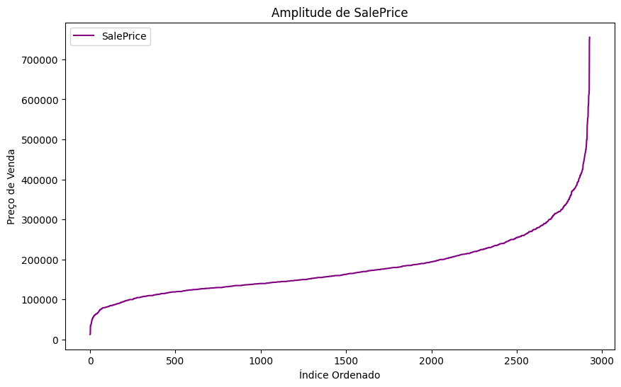

```python
plt.figure(figsize=(10, 6))
plt.plot(np.sort(y), label="SalePrice", color='purple')
plt.title("Amplitude de SalePrice")
plt.xlabel("Índice Ordenado")
plt.ylabel("Preço de Venda")
plt.legend()
plt.show()
```

Ordenando a variável `SalePrice` observa-se sua amplitude, destacando uma curva crescente acentuada para as propriedades de maior valor. A maior parte dos preços está concentrada em faixas moderadas, enquanto os valores mais altos representam outliers ou propriedades de luxo. Essa visualização ajuda a identificar a assimetria e a variabilidade dos dados, elementos que influenciarão diretamente as etapas de modelagem e análise.

##### 3.1.3.2 Plot - boxplot

Índice

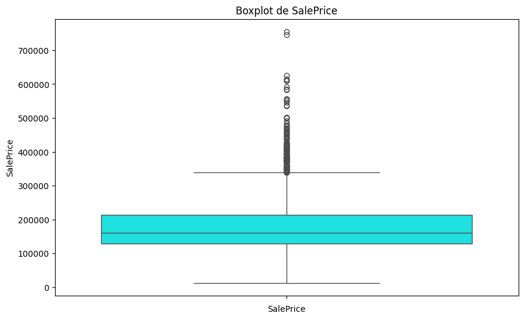

```python
plt.figure(figsize=(10, 6))
sns.boxplot(y=y, color='cyan')
plt.title("Boxplot de SalePrice")
plt.xlabel("SalePrice")
plt.show()
```

O boxplot da variável `SalePrice` fornece informações importantes sobre a distribuição dos preços de venda. A mediana está localizada dentro da faixa interquartílica relativamente estreita, indicando que a maior parte dos preços está concentrada em torno de valores moderados. O gráfico destaca a presença de diversos outliers acima do limite superior, representando propriedades com preços extremamente altos. Esses outliers podem ter impacto significativo na modelagem e devem ser considerados no processo de análise, especialmente na validação dos pressupostos estatísticos.

##### 3.1.3.3 Plots Variável Dependente

Índice

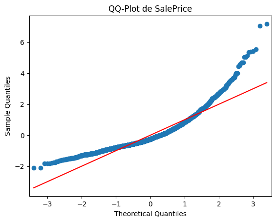

```python
# Gráfico de QQ-Plot para verificar normalidade
plt.figure(figsize=(10, 6))
sm.qqplot(y, line='s', fit=True)
plt.title("QQ-Plot de SalePrice")
plt.show()
```

O QQ-Plot da variável `SalePrice` avalia a aderência dos dados à normalidade. Observa-se que, embora os dados centrais estejam próximos da linha de referência, os extremos (valores mais baixos e mais altos) desviam significativamente, indicando caudas longas. Esse padrão sugere que a variável não segue uma distribuição normal perfeita, o que pode impactar análises que assumem normalidade. Transformações, como o logaritmo, podem ser consideradas para corrigir essa característica, se necessário para a modelagem.

##### 3.1.3.4 Distribuição Dados - skw/Kurt

Índice

```python
# Estatísticas descritivas adicionais
print("Skewness (Assimetria):", skew(y))
print("Kurtosis (Curtose):", kurtosis(y))
```

```
Skewness (Assimetria): 1.7426236420109267
Kurtosis (Curtose): 5.107524847568088
```

A análise da assimetria (1,743) e da curtose (5,108) reforça as observações do QQ-Plot. A assimetria positiva indica uma distribuição com cauda longa à direita, causada por propriedades com preços muito elevados. Já a curtose elevada reflete caudas mais pesadas do que a normalidade, indicando a presença de outliers. Esses fatores sugerem a possibilidade de transformações para ajustar a variável SalePrice e melhorar a adequação dos modelos estatísticos.

##### 3.1.3.5 Relações Variável Dependente

Índice

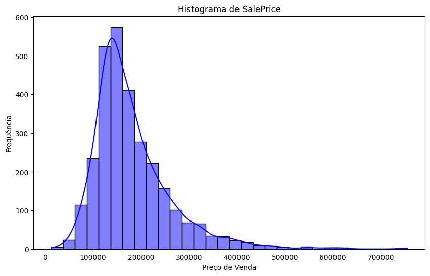

```python
plt.figure(figsize=(10, 6))
sns.histplot(y, kde=True, bins=30, color='blue')
plt.title("Histograma de SalePrice")
plt.xlabel("Preço de Venda")
plt.ylabel("Frequência")
plt.show()
```

O histograma da variável `SalePrice` mostra uma distribuição assimétrica à direita, confirmando a presença de propriedades com preços significativamente mais altos que a maioria. A maioria das observações está concentrada na faixa de $100.000 a $200.000. Se assimetria dos dados for sensível ao modelo de ML é um indício claro que deverá considerar transformações para corrigir a serem feitas antes da modelagem.

#### 3.1.4 Análise da Variáveis Explanatórias

Uma variável independente **X** explica a variação em outra variável, que é chamada variável dependente *y*. Este relacionamento existe em apenas uma direção:

```
  variável independente (**X**) **->** variável dependente (*y*)
```

Índice

```python
X.head()
```

|  | Gr Liv Area | Garage Cars | Total Bsmt SF | Lot Area | Overall Qual | Kitchen Qual | Overall Cond | Fireplaces | Wood Deck SF | Bedroom AbvGr | TotRms AbvGrd | HouseAge | Full Bath | Bldg Type |
| --- | --- | --- | --- | --- | --- | --- | --- | --- | --- | --- | --- | --- | --- | --- |
| 0 | 1656 | 2.0 | 1080.0 | 31770 | 6 | TA | 5 | 2 | 210 | 3 | 7 | 64 | 1 | 1Fam |
| 1 | 896 | 1.0 | 882.0 | 11622 | 5 | TA | 6 | 0 | 140 | 2 | 5 | 63 | 1 | 1Fam |
| 2 | 1329 | 1.0 | 1329.0 | 14267 | 6 | Gd | 6 | 0 | 393 | 3 | 6 | 66 | 1 | 1Fam |
| 3 | 2110 | 2.0 | 2110.0 | 11160 | 7 | Ex | 5 | 2 | 0 | 3 | 8 | 56 | 2 | 1Fam |
| 4 | 1629 | 2.0 | 928.0 | 13830 | 5 | TA | 5 | 1 | 212 | 3 | 6 | 27 | 2 | 1Fam |

As variáveis explicativas selecionadas foram analisadas individualmente para entender a relação entre cada uma delas e a variável dependente `SalePrice`. Essa análise ajuda a identificar padrões importantes e avaliar a força das associações.

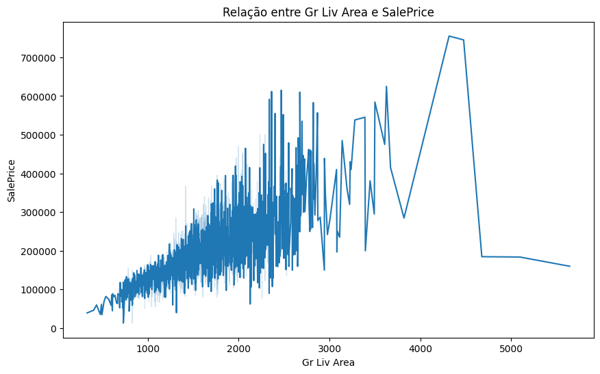

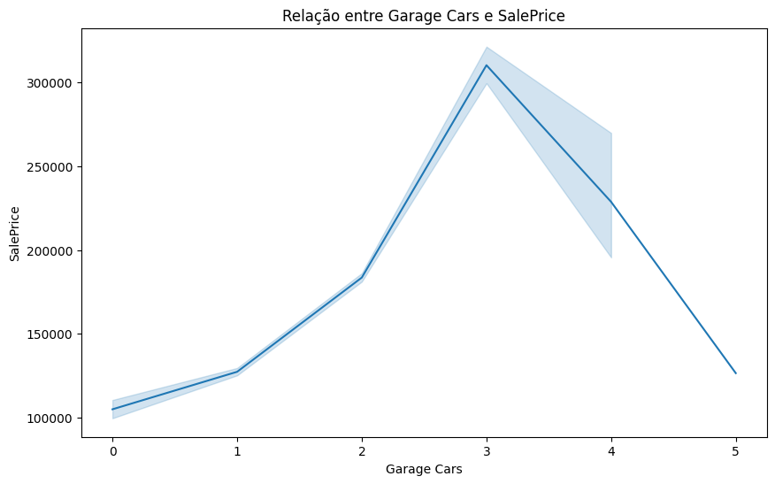

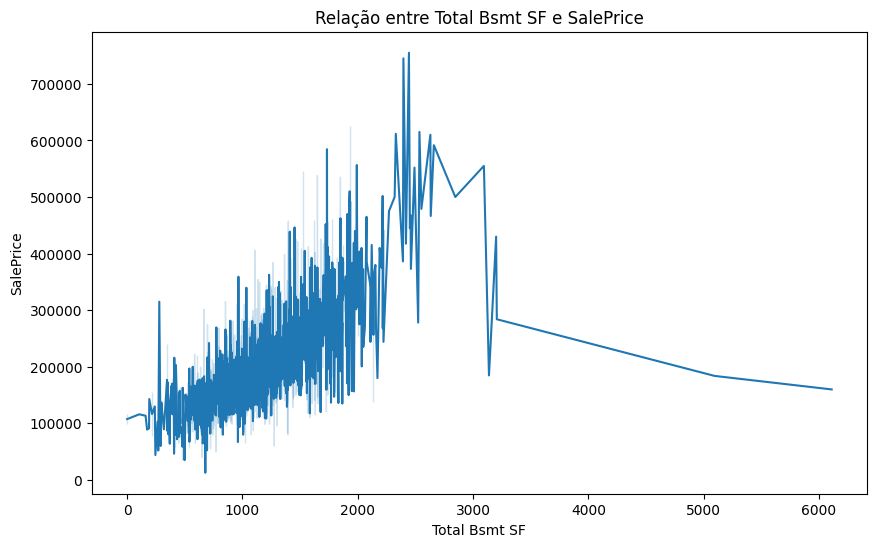

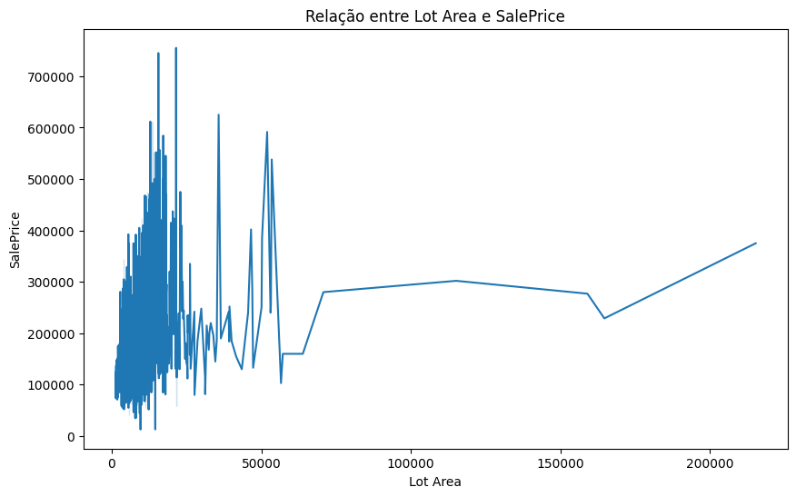

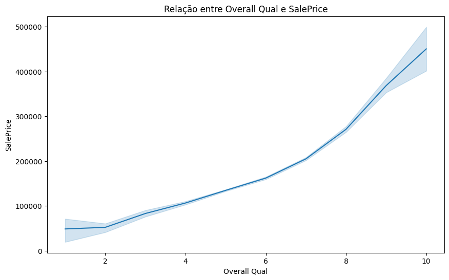

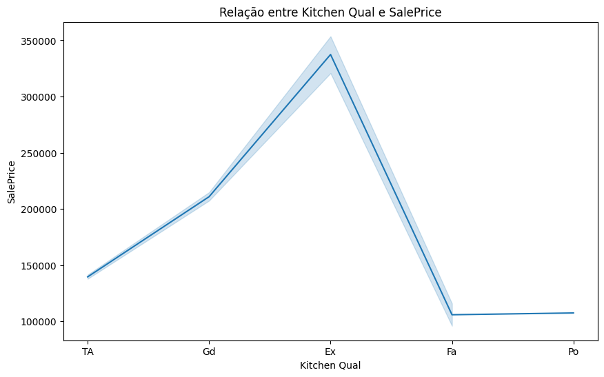

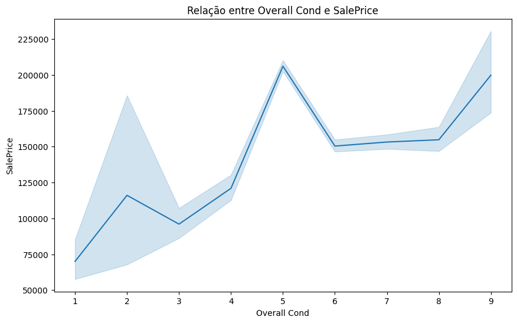

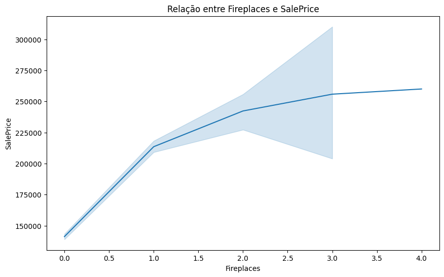

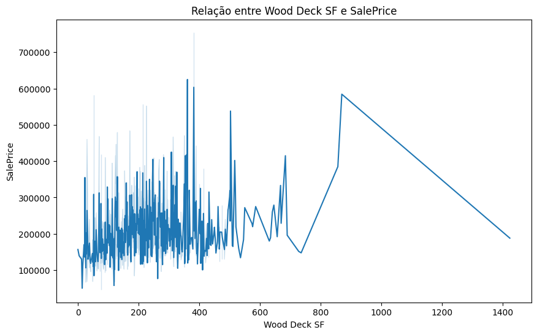

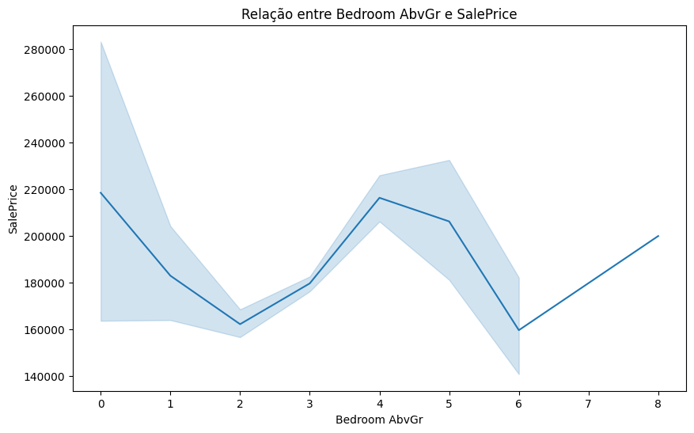

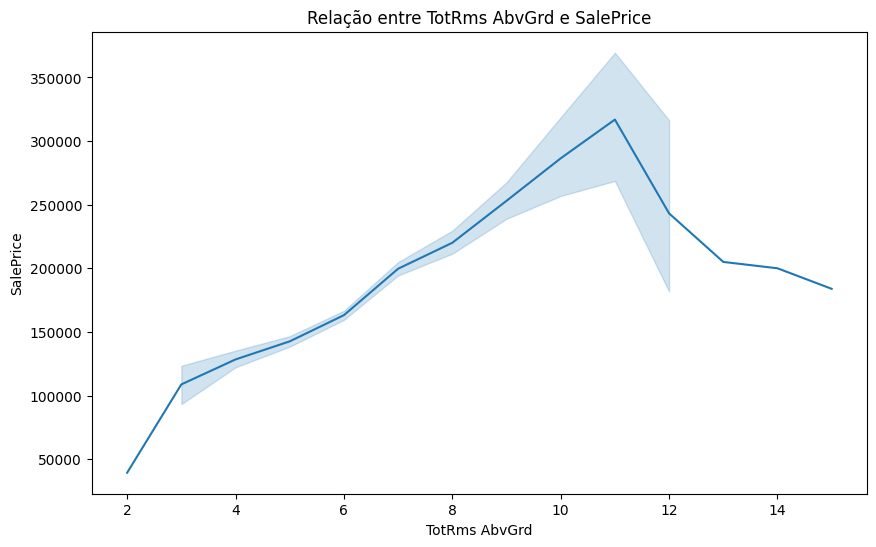

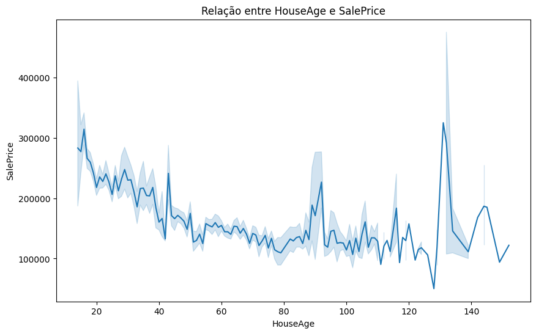

[2 more figures not shown]

```python
for feature in selected_features:
    plt.figure(figsize=(10, 6))
    sns.lineplot(x=X[feature], y=y, palette="viridis")
    plt.title(f"Relação entre {feature} e SalePrice")
    plt.xlabel(feature)
    plt.ylabel("SalePrice")
    plt.show()
```

Podemos realizar algumas considerações e com base no comportamento das preditoras com a variável alvo ter algumas compreensões, como:

A variável `HouseAge` representa a idade da propriedade, calculada a partir do ano de construção. Essa variável é comumente associada à depreciação do imóvel, especialmente para construções mais antigas. Pode-se observar que o gráfico revela uma relação inversa com o preço de venda: imóveis mais antigos tendem a ter preços mais baixos, enquanto imóveis mais recentes mantêm valores mais elevados.

Para a variável `Fireplaces` que reflete o número de lareiras presentes na propriedade. Este elemento é frequentemente associado ao conforto e à sofisticação estética do imóvel. Sugere uma relação positiva entre o número de lareiras e o preço de venda. Propriedades com uma ou duas lareiras mostram um aumento expressivo nos preços. Contudo, o impacto adicional diminui a partir de três lareiras, possivelmente devido a limitações práticas ou menor representatividade de imóveis com um número maior de lareiras nos dados.

Uma outra variável que podemos tecer uma avaliação é a `KitchenQual` que avalia a qualidade da cozinha em categorias, como Excelente (Ex), Boa (Gd), Típica/Adequada (TA), e Fraca (Fa). A relação com `SalePrice` é claramente positiva, especialmente em categorias de qualidade superior. Sendo assim, propriedades com cozinhas de qualidade "Excelente" apresentam os maiores preços médios, enquanto aquelas classificadas como "Fraca" têm preços significativamente menores. Essa diferença destaca a direção do impacto que a qualidade da cozinha pode ter na valorização da propriedade.

##### 3.1.4.1 Classificação das variáveis por tipo de dados

Índice

```python
X.info()
```

```
<class 'pandas.core.frame.DataFrame'>
Index: 2928 entries, 0 to 2929
Data columns (total 14 columns):
 #   Column         Non-Null Count  Dtype
---  ------         --------------  -----
 0   Gr Liv Area    2928 non-null   int64
 1   Garage Cars    2928 non-null   float64
 2   Total Bsmt SF  2928 non-null   float64
 3   Lot Area       2928 non-null   int64
 4   Overall Qual   2928 non-null   int64
 5   Kitchen Qual   2928 non-null   object
 6   Overall Cond   2928 non-null   int64
 7   Fireplaces     2928 non-null   int64
 8   Wood Deck SF   2928 non-null   int64
 9   Bedroom AbvGr  2928 non-null   int64
 10  TotRms AbvGrd  2928 non-null   int64
 11  HouseAge       2928 non-null   int64
 12  Full Bath      2928 non-null   int64
 13  Bldg Type      2928 non-null   object
dtypes: float64(2), int64(10), object(2)
memory usage: 343.1+ KB
```

##### 3.1.4.2 Explanatórias Numéricas

Índice

```python
numerical_features = [
        "Gr Liv Area", "Garage Cars", "Total Bsmt SF", "Lot Area", "Fireplaces",
    "Wood Deck SF", "Bedroom AbvGr", "TotRms AbvGrd", "HouseAge", "Full Bath"
]
```

##### 3.1.4.2.1 Plot - scatterplots

Índice

Os gráficos gerados com a combinação de scatterplot e regplot apresentam, simultaneamente, os dados de dispersão e a linha de regressão linear para cada variável numérica selecionada. Permitem visualizar as relações entre as variáveis explanatórias e a variável dependente `SalePrice`. A dispersão dos pontos fornece insights sobre a variação dos preços de venda em função de cada característica, enquanto a linha de regressão destaca a tendência geral da relação. Essa abordagem facilita a identificação de padrões, possíveis associações lineares, outliers e comportamentos não lineares que podem impactar a modelagem.

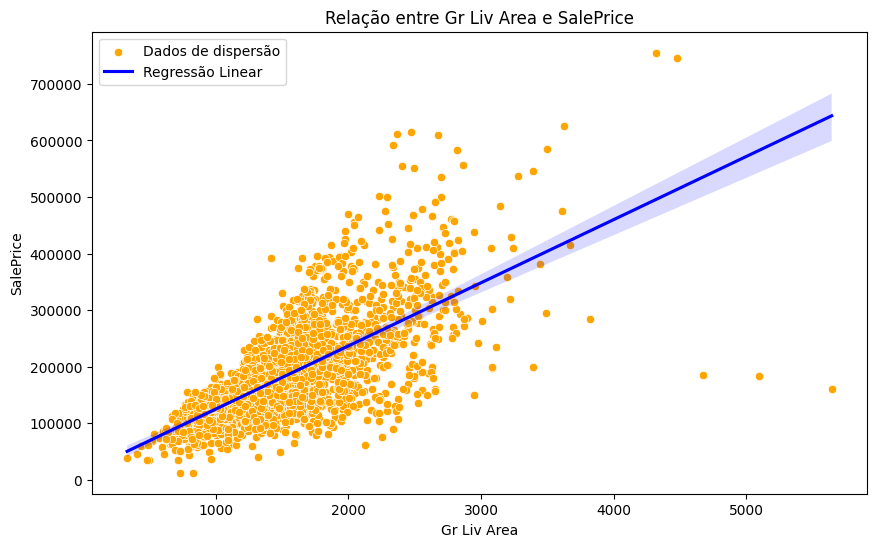

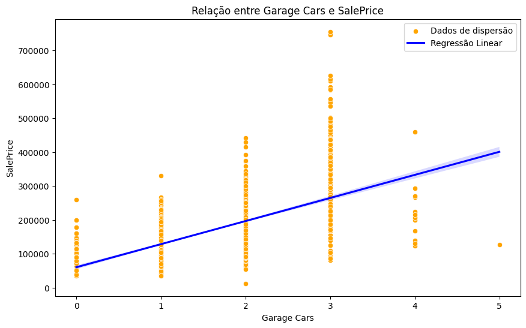

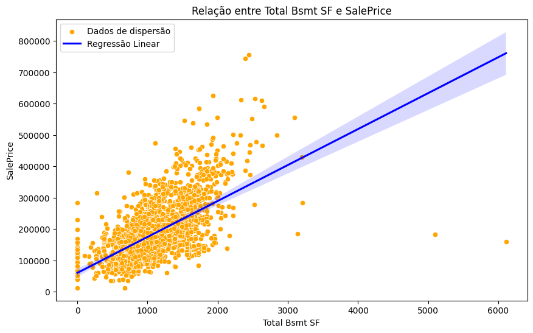

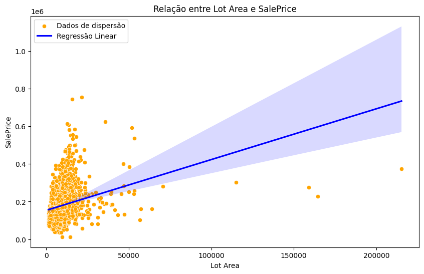

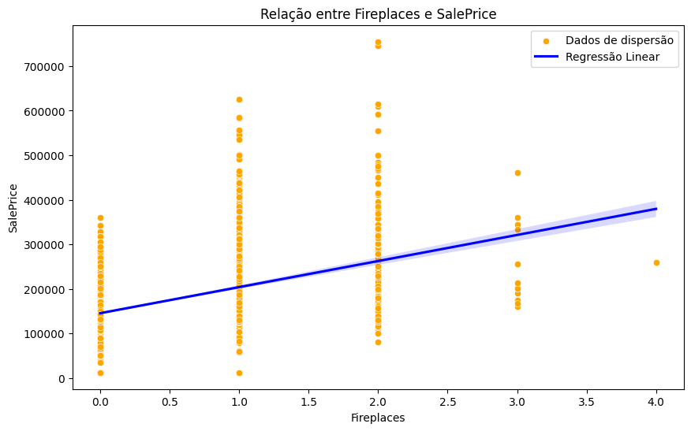

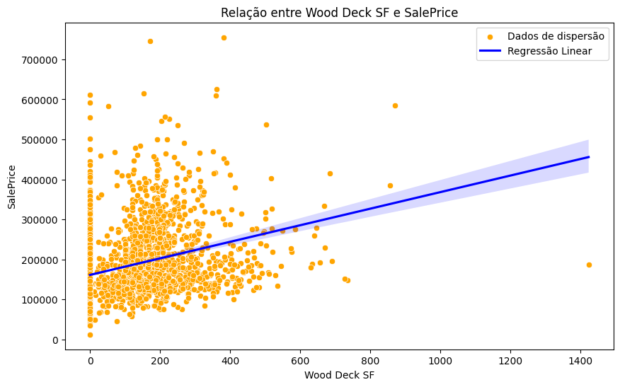

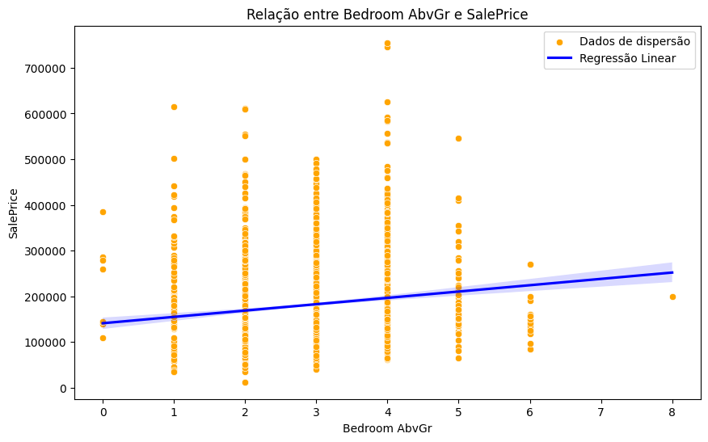

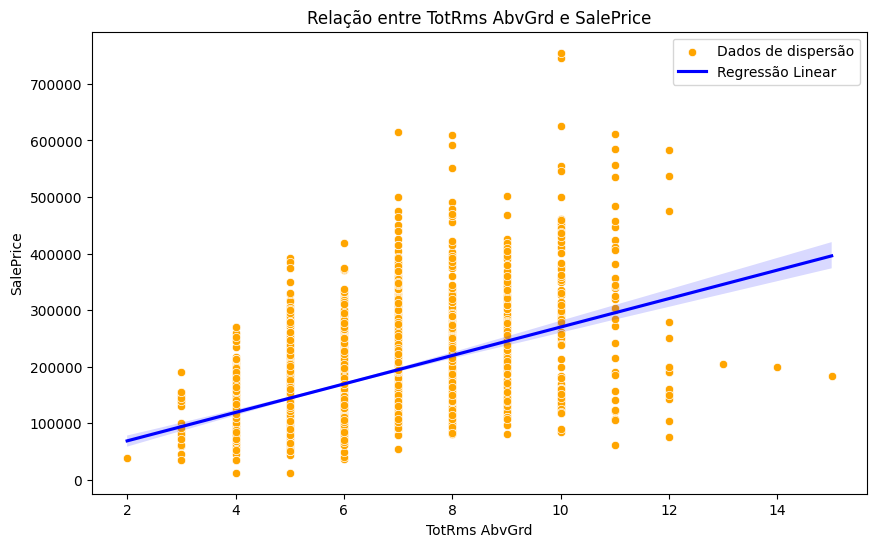

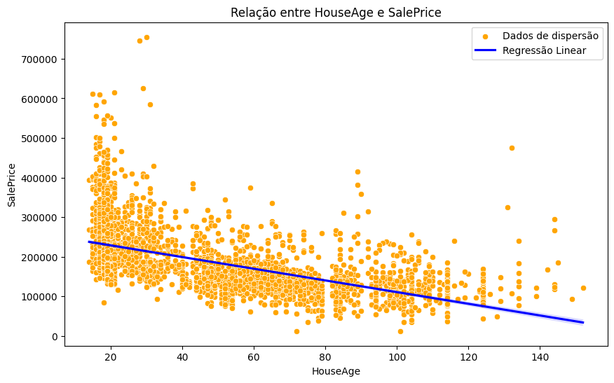

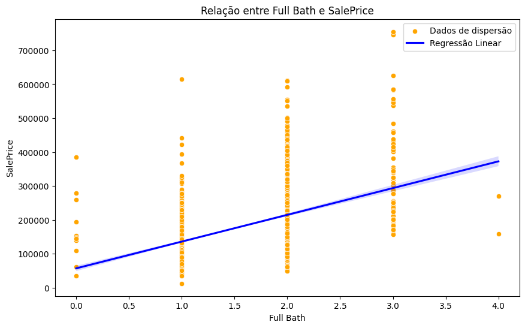

```python
for feature in numerical_features:
    plt.figure(figsize=(10, 6))
    sns.scatterplot(x=X[feature], y=y, color='orange', label='Dados de dispersão')
    sns.regplot(x=X[feature], y=y, scatter=False, color='blue', label='Regressão Linear')
    plt.title(f"Relação entre {feature} e SalePrice")
    plt.xlabel(feature)
    plt.ylabel("SalePrice")
    plt.legend()
    plt.show()
```

##### 3.1.4.2.2 Correlação Atributos

Índice

```python
X[numerical_features].corr()
```

|  | Gr Liv Area | Garage Cars | Total Bsmt SF | Lot Area | Fireplaces | Wood Deck SF | Bedroom AbvGr | TotRms AbvGrd | HouseAge | Full Bath |
| --- | --- | --- | --- | --- | --- | --- | --- | --- | --- | --- |
| Gr Liv Area | 1.000000 | 0.488621 | 0.444819 | 0.285517 | 0.455029 | 0.249830 | 0.516607 | 0.807800 | -0.241949 | 0.630107 |
| Garage Cars | 0.488621 | 1.000000 | 0.437608 | 0.179368 | 0.320990 | 0.241035 | 0.091036 | 0.355230 | -0.537312 | 0.477997 |
| Total Bsmt SF | 0.444819 | 0.437608 | 1.000000 | 0.253577 | 0.333007 | 0.230049 | 0.051969 | 0.280721 | -0.407479 | 0.325135 |
| Lot Area | 0.285517 | 0.179368 | 0.253577 | 1.000000 | 0.256865 | 0.157141 | 0.136421 | 0.216403 | -0.023044 | 0.127326 |
| Fireplaces | 0.455029 | 0.320990 | 0.333007 | 0.256865 | 1.000000 | 0.228134 | 0.076737 | 0.302503 | -0.170046 | 0.229850 |
| Wood Deck SF | 0.249830 | 0.241035 | 0.230049 | 0.157141 | 0.228134 | 1.000000 | 0.029422 | 0.154494 | -0.229263 | 0.179224 |
| Bedroom AbvGr | 0.516607 | 0.091036 | 0.051969 | 0.136421 | 0.076737 | 0.029422 | 1.000000 | 0.672529 | 0.055334 | 0.359251 |
| TotRms AbvGrd | 0.807800 | 0.355230 | 0.280721 | 0.216403 | 0.302503 | 0.154494 | 0.672529 | 1.000000 | -0.111429 | 0.528506 |
| HouseAge | -0.241949 | -0.537312 | -0.407479 | -0.023044 | -0.170046 | -0.229263 | 0.055334 | -0.111429 | 1.000000 | -0.469936 |
| Full Bath | 0.630107 | 0.477997 | 0.325135 | 0.127326 | 0.229850 | 0.179224 | 0.359251 | 0.528506 | -0.469936 | 1.000000 |

##### 3.1.4.2.3 Plot - Matriz de Correlação

Índice

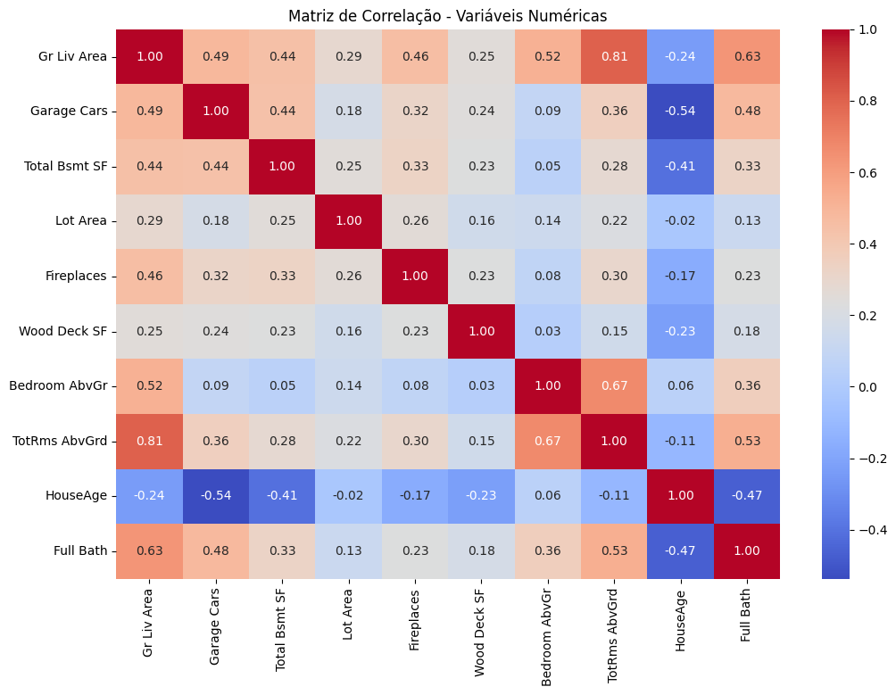

```python
plt.figure(figsize=(12, 8))
correlation_matrix = X[numerical_features].corr()
sns.heatmap(correlation_matrix, annot=True, cmap="coolwarm", fmt=".2f")
plt.title("Matriz de Correlação - Variáveis Numéricas")
plt.show()
```

A matriz de correlação permite identificar a relação linear entre variáveis numéricas. Nesse contexto, cada valor da matriz, variando entre -1 e 1, indica a força e a direção do relacionamento entre duas variáveis. Valores próximos de 1 representam uma correlação positiva forte, enquanto valores próximos de -1 indicam uma correlação negativa forte. Já valores próximos de 0 sugerem ausência de relação linear significativa. (Silva, 2023)

No gráfico, as cores facilitam a interpretação visual: tons avermelhados indicam correlação positiva, enquanto tons azulados representam correlação negativa. Por exemplo, observa-se uma forte correlação positiva entre `Gr Liv Area` e `TotRms Abv Grd` (0.81), indicando que, em geral, propriedades com maior área habitável acima do solo tendem a ter mais cômodos. Por outro lado, variáveis como `HouseAge` apresentam correlações negativas moderadas com outras variáveis, como `Garage Cars` (-0.54), sugerindo que casas mais antigas tendem a ter garagens menores. Essa análise permite identificar variáveis altamente correlacionadas, que podem influenciar a multicolinearidade nos modelos de regressão.

##### 3.1.4.2.4 Avaliando a Multicolinearidade

A avaliação de multicolinearidade é um passo essencial em análises de regressão linear, pois a presença de correlações elevadas entre variáveis explicativas pode distorcer os coeficientes do modelo, dificultando a interpretação e reduzindo sua precisão preditiva. Uma das ferramentas mais utilizadas para diagnosticar multicolinearidade é o Fator de Inflação da Variância (Variance Inflation Factor - VIF). O VIF mede o quanto a variância de um coeficiente de regressão é inflada devido à correlação entre variáveis explicativas. (Gujarati, 2009)

Vlores de VIF acima de 10 são geralmente considerados indicadores de multicolinearidade severa, enquanto valores próximos de 1 sugerem baixa correlação. Essa métrica ajuda a identificar quais variáveis podem ser redundantes e devem ser ajustadas ou removidas do modelo, melhorando sua robustez e interpretabilidade.

Índice

```python
vif_data = pd.DataFrame()
vif_data["Feature"] = numerical_features
vif_data["VIF"] = [variance_inflation_factor(X[numerical_features].values, i) for i in range(X[numerical_features].shape[1])]
```

```python
print("\nVariance Inflation Factor (VIF):")
print(vif_data)
```

```
Variance Inflation Factor (VIF):
         Feature        VIF
0    Gr Liv Area  40.391979
1    Garage Cars  10.312104
2  Total Bsmt SF   8.848557
3       Lot Area   3.078425
4     Fireplaces   2.575616
5   Wood Deck SF   1.751656
6  Bedroom AbvGr  25.504382
7  TotRms AbvGrd  64.253768
8       HouseAge   4.314102
9      Full Bath  16.892883
```

> "Em geral, considera-se um problema VIF > 5. Mas esta é uma regra de bolso. Há quem diga que acima de 10 é que se deve corrigir o problema de colinearidade... Algumas alternativas para solucionar problemas de multicolinearidade são: regressão por mínimos quadrados parciais (partial least squares, do inglês), regressão de componentes principais (similar a última), regressão de cumeeira (ridge regression)."  
> *(Silva, 2023, p. 199)*

Um dos pressupostos fundamentais da regressão linear, que é a ausência de multicolinearidade entre as variáveis independentes, foi claramente violado, conforme evidenciado pelos valores do VIF. Variáveis como `Gr Liv Area` (VIF = 40.39), `TotRms AbvGrd` (VIF = 64.25) e `Bedroom AbvGr` (VIF = 25.50) indicam níveis de multicolinearidade. Essa condição compromete a estabilidade e a interpretabilidade do modelo, podendo inflacionar os erros padrão dos coeficientes e dificultar a identificação da real contribuição de cada variável na previsão.

No entanto, usaremos a "Licença científica" e seguiremos em frente para explorar como o modelo se comporta, reconhecendo que, conforme o ciclo CRISP-DM, a transição entre as etapas de **preparação dos dados** e **modelagem** pode ser feita iterativamente. Isso permite revisitar as etapas, ajustar o tratamento de multicolinearidade e refinar o modelo conforme necessário, garantindo maior robustez e adequação aos dados ao longo do processo.

##### 3.1.4.3 Explanatórias Categóricas

Essa etapa dá continuidade à análise das variáveis explicativas, focando nos dados categóricos. Utilizamos o boxplot como ferramenta principal para visualizar a distribuição da variável resposta em cada categoria, o que permite identificar diferenças significativas entre grupos, detectar outliers e avaliar tendências gerais. Esses insights ajudam a determinar se as categorias possuem poder explicativo relevante para o modelo, guiando ajustes e decisões na preparação dos dados.

Índice

```python
categorical_features = ["Overall Qual", "Kitchen Qual", "Overall Cond", "Bldg Type"]
```

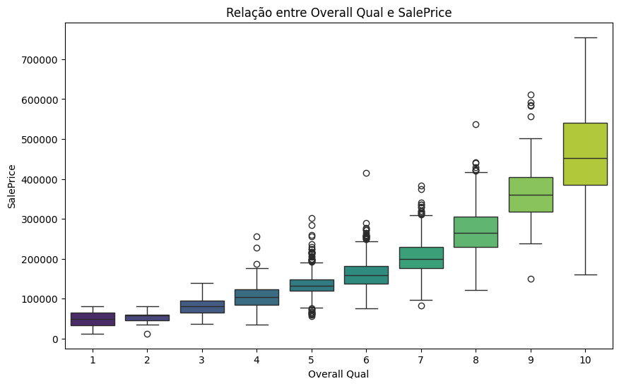

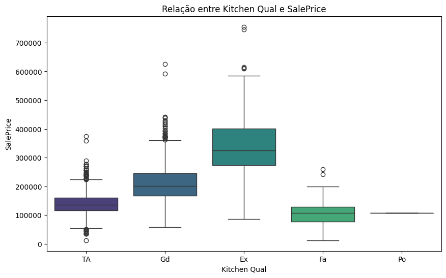

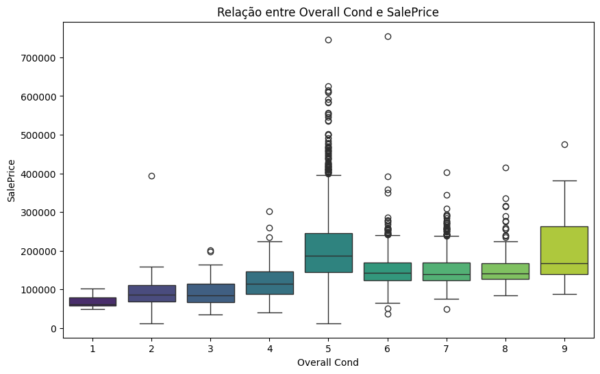

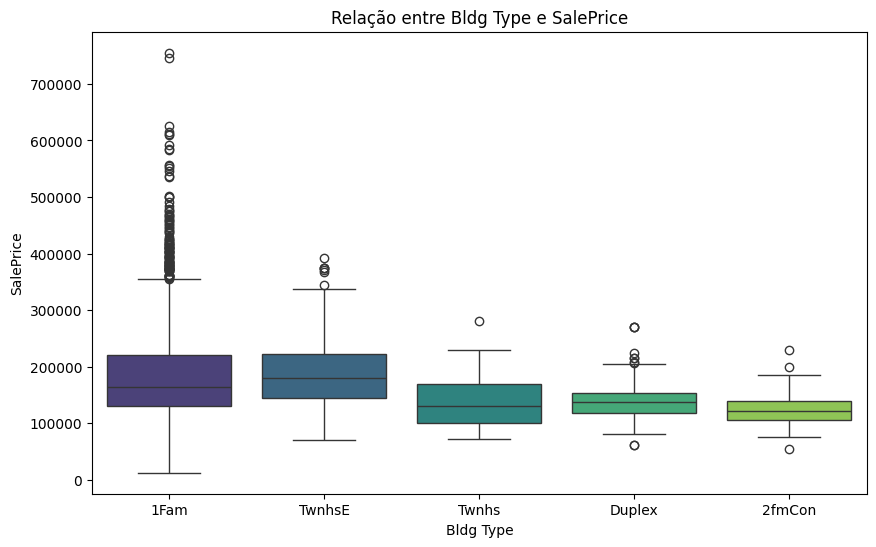

```python
for feature in categorical_features:
    plt.figure(figsize=(10, 6))
    sns.boxplot(x=data[feature], y=y, palette="viridis")
    plt.title(f"Relação entre {feature} e SalePrice")
    plt.xlabel(feature)
    plt.ylabel("SalePrice")
    plt.show()
```

## 4. Pré-Processamento dados

Índice

### 4.1 Feature Engineer

Após a Análise Exploratória dos Dados (EDA), iniciamos a etapa de pré-processamento, essencial para preparar os dados de forma adequada para a modelagem.

Nesse trabalho, **(i)** transformamos variáveis categóricas em variáveis dummy, permitindo que classes representadas como strings sejam convertidas em um formato numérico compreensível para os algoritmos de aprendizado. Além disso, **(ii)** tratamos os valores ausentes, optando por remover observações com dados faltantes, dado seu impacto mínimo (apenas 2 registros).

Essas ações visam garantir que os dados estejam limpos, estruturados e prontos para alimentar o modelo, maximizando sua eficácia e desempenho.

Índice

#### 4.1.1 Dummies

Técnica de entregar a var_Categóricas, formato numérico sem perder representação da informação

Índice

```python
X
```

|  | Gr Liv Area | Garage Cars | Total Bsmt SF | Lot Area | Overall Qual | Kitchen Qual | Overall Cond | Fireplaces | Wood Deck SF | Bedroom AbvGr | TotRms AbvGrd | HouseAge | Full Bath | Bldg Type |
| --- | --- | --- | --- | --- | --- | --- | --- | --- | --- | --- | --- | --- | --- | --- |
| 0 | 1656 | 2.0 | 1080.0 | 31770 | 6 | TA | 5 | 2 | 210 | 3 | 7 | 64 | 1 | 1Fam |
| 1 | 896 | 1.0 | 882.0 | 11622 | 5 | TA | 6 | 0 | 140 | 2 | 5 | 63 | 1 | 1Fam |
| 2 | 1329 | 1.0 | 1329.0 | 14267 | 6 | Gd | 6 | 0 | 393 | 3 | 6 | 66 | 1 | 1Fam |
| 3 | 2110 | 2.0 | 2110.0 | 11160 | 7 | Ex | 5 | 2 | 0 | 3 | 8 | 56 | 2 | 1Fam |
| 4 | 1629 | 2.0 | 928.0 | 13830 | 5 | TA | 5 | 1 | 212 | 3 | 6 | 27 | 2 | 1Fam |
| ... | ... | ... | ... | ... | ... | ... | ... | ... | ... | ... | ... | ... | ... | ... |
| 2925 | 1003 | 2.0 | 1003.0 | 7937 | 6 | TA | 6 | 0 | 120 | 3 | 6 | 40 | 1 | 1Fam |
| 2926 | 902 | 2.0 | 864.0 | 8885 | 5 | TA | 5 | 0 | 164 | 2 | 5 | 41 | 1 | 1Fam |
| 2927 | 970 | 0.0 | 912.0 | 10441 | 5 | TA | 5 | 0 | 80 | 3 | 6 | 32 | 1 | 1Fam |
| 2928 | 1389 | 2.0 | 1389.0 | 10010 | 5 | TA | 5 | 1 | 240 | 2 | 6 | 50 | 1 | 1Fam |
| 2929 | 2000 | 3.0 | 996.0 | 9627 | 7 | TA | 5 | 1 | 190 | 3 | 9 | 31 | 2 | 1Fam |

2928 rows × 14 columns

```python
categorical_features_dummies = ['Kitchen Qual','Bldg Type']
```

```python
X = pd.get_dummies(X, columns=categorical_features_dummies, drop_first=True)
```

```python
X
```

|  | Gr Liv Area | Garage Cars | Total Bsmt SF | Lot Area | Overall Qual | Overall Cond | Fireplaces | Wood Deck SF | Bedroom AbvGr | TotRms AbvGrd | HouseAge | Full Bath | Kitchen Qual_Fa | Kitchen Qual_Gd | Kitchen Qual_Po | Kitchen Qual_TA | Bldg Type_2fmCon | Bldg Type_Duplex | Bldg Type_Twnhs | Bldg Type_TwnhsE |
| --- | --- | --- | --- | --- | --- | --- | --- | --- | --- | --- | --- | --- | --- | --- | --- | --- | --- | --- | --- | --- |
| 0 | 1656 | 2.0 | 1080.0 | 31770 | 6 | 5 | 2 | 210 | 3 | 7 | 64 | 1 | False | False | False | True | False | False | False | False |
| 1 | 896 | 1.0 | 882.0 | 11622 | 5 | 6 | 0 | 140 | 2 | 5 | 63 | 1 | False | False | False | True | False | False | False | False |
| 2 | 1329 | 1.0 | 1329.0 | 14267 | 6 | 6 | 0 | 393 | 3 | 6 | 66 | 1 | False | True | False | False | False | False | False | False |
| 3 | 2110 | 2.0 | 2110.0 | 11160 | 7 | 5 | 2 | 0 | 3 | 8 | 56 | 2 | False | False | False | False | False | False | False | False |
| 4 | 1629 | 2.0 | 928.0 | 13830 | 5 | 5 | 1 | 212 | 3 | 6 | 27 | 2 | False | False | False | True | False | False | False | False |
| ... | ... | ... | ... | ... | ... | ... | ... | ... | ... | ... | ... | ... | ... | ... | ... | ... | ... | ... | ... | ... |
| 2925 | 1003 | 2.0 | 1003.0 | 7937 | 6 | 6 | 0 | 120 | 3 | 6 | 40 | 1 | False | False | False | True | False | False | False | False |
| 2926 | 902 | 2.0 | 864.0 | 8885 | 5 | 5 | 0 | 164 | 2 | 5 | 41 | 1 | False | False | False | True | False | False | False | False |
| 2927 | 970 | 0.0 | 912.0 | 10441 | 5 | 5 | 0 | 80 | 3 | 6 | 32 | 1 | False | False | False | True | False | False | False | False |
| 2928 | 1389 | 2.0 | 1389.0 | 10010 | 5 | 5 | 1 | 240 | 2 | 6 | 50 | 1 | False | False | False | True | False | False | False | False |
| 2929 | 2000 | 3.0 | 996.0 | 9627 | 7 | 5 | 1 | 190 | 3 | 9 | 31 | 2 | False | False | False | True | False | False | False | False |

2928 rows × 20 columns

#### 4.1.2 Imputação Missing

Realizado no item 3.1.2

Índice

```python
# X = X.dropna()
# y = y[X.index]
```

### 4.2 Split dados

Para avaliar o desempenho do modelo, é fundamental dividir os dados em conjuntos de treino e teste. Duas abordagens amplamente utilizadas são:

- (i) o método estático, implementado pela função train_test_split da biblioteca sklearn.model_selection, que separa os dados em uma única iteração; e
- (ii) a validação cruzada (Cross-validation), que realiza divisões aleatórias e avalia o modelo em diferentes subconjuntos para maior robustez.

Optamos pelo método estático, configurando 80% dos dados para treino e 20% para teste, garantindo simplicidade e uma divisão consistente para o desenvolvimento inicial do modelo.

Índice

#### 4.2.1 Estático - nível linha

Índice

```python
X_train, X_test, y_train, y_test = train_test_split(X, y, test_size=0.2, random_state=42)
```

= output: dados pré-processados e splitados para iniciar a construção do modelo de ML

## 5. Seleção Algoritmos

### 5.1 Algoritmos Regressores

A regressão linear é uma técnica estatística utilizada para prever o valor de uma variável dependente (contínua) com base em uma ou mais variáveis independentes. O objetivo é estabelecer um modelo matemático que expresse a relação entre as variáveis, permitindo entender como determinadas variáveis explicativas influenciam a resposta. Um exemplo de seu uso é prever o preço de uma casa com base em seu tamanho, onde o preço é a variável dependente e o tamanho, a variável independente, ou seja, o objetivo do presente.

A abordagem baseia-se na suposição de que as variáveis estão linearmente relacionadas, permitindo que a relação seja descrita por uma equação linear simples ou múltipla. Para construir o modelo, é necessário treinar o algoritmo com dados históricos, identificar os padrões matemáticos subjacentes e, em seguida, usar esses padrões para fazer previsões. Essa simplicidade faz da regressão linear uma ferramenta amplamente utilizada em diversas áreas, como finanças, engenharia, e claro ciência de dados.

Além de sua facilidade de implementação, a regressão linear fornece coeficientes que são facilmente interpretáveis, permitindo compreender o impacto de cada variável independente na resposta. No entanto, sua aplicabilidade depende de atender a pressupostos importantes, como linearidade, homocedasticidade, independência dos erros e ausência de multicolinearidade.

Índice

### 5.1.1 Regressão Linear

Índice

Assume que os **dados estão em Distribuição Normal** e também assume que as **variáveis são relevantes** para a construção do modelo e que **não sejam colineares**, ou seja, variáveis com alta correlação (deve-se entregar ao algoritmo as variáveis realmente relevantes).

```python
model = LinearRegression()
```

```python
print(X.dtypes)
```

```
Gr Liv Area           int64
Garage Cars         float64
Total Bsmt SF       float64
Lot Area              int64
Overall Qual          int64
Overall Cond          int64
Fireplaces            int64
Wood Deck SF          int64
Bedroom AbvGr         int64
TotRms AbvGrd         int64
HouseAge              int64
Full Bath             int64
Kitchen Qual_Fa        bool
Kitchen Qual_Gd        bool
Kitchen Qual_Po        bool
Kitchen Qual_TA        bool
Bldg Type_2fmCon       bool
Bldg Type_Duplex       bool
Bldg Type_Twnhs        bool
Bldg Type_TwnhsE       bool
dtype: object
```

```python
model.fit(X_train, y_train)
```

```
LinearRegression()
```

```python
coefficients = pd.DataFrame({"Feature": X.columns, "Coefficient": model.coef_})
intercept = model.intercept_
```

```python
y_pred_train = model.predict(X_train)
y_pred_test = model.predict(X_test)

residuals = y_test - y_pred_test
```

```python
print("Coeficientes do modelo:")
print(coefficients)
```

```
Coeficientes do modelo:
             Feature   Coefficient
0        Gr Liv Area  5.284067e+01
1        Garage Cars  9.268205e+03
2      Total Bsmt SF  2.267557e+01
3           Lot Area  4.781547e-01
4       Overall Qual  1.386263e+04
5       Overall Cond  5.613652e+03
6         Fireplaces  6.895560e+03
7       Wood Deck SF  2.425044e+01
8      Bedroom AbvGr -7.058272e+03
9      TotRms AbvGrd  3.912949e+02
10          HouseAge -5.117012e+02
11         Full Bath -7.757054e+02
12   Kitchen Qual_Fa -4.978184e+04
13   Kitchen Qual_Gd -5.009302e+04
14   Kitchen Qual_Po  1.818989e-11
15   Kitchen Qual_TA -5.701537e+04
16  Bldg Type_2fmCon -5.484163e+03
17  Bldg Type_Duplex -1.590632e+04
18   Bldg Type_Twnhs -2.308489e+04
19  Bldg Type_TwnhsE -1.510283e+04
```

Coeficientes **𝛽 positivos** indicam que, à medida que a variável explicativa associada aumenta (mantendo as outras constantes), o preço da variável dependente *𝑦* também aumenta. Ou seja, essas variáveis têm um impacto positivo no preço.

Coeficientes **𝛽 negativos** indicam que, à medida que a variável explicativa associada aumenta, o preço (*𝑦*) diminui, tendo um impacto negativo no preço.

Essa relação é direta, e a magnitude do coeficiente representa o impacto médio da variável na resposta *𝑦*. Por exemplo:

- Se 𝛽=50, um aumento de 1 unidade na variável 𝑥 correspondente resultará em um aumento médio de 50 unidades no preço (𝑦).
- Se 𝛽= −30, um aumento de 1 unidade em 𝑥 reduzirá, em média, o preço em 30 unidades.

Em termos práticos temos:

- `Gr Liv Area` (52,84): A cada unidade adicional de área habitável, o valor predito aumenta em aproximadamente 52,84 unidades monetárias, mantendo as outras variáveis constantes.
- `Garage Cars` (9.268,21): Cada vaga adicional na garagem está associada a um aumento médio de 9.268,21 no valor predito.
- `Overall Qual` (13.862,63): Para cada ponto a mais na qualidade geral do imóvel, o valor predito aumenta em 13.862,63.
- `Fireplaces` (6.895,56): Cada lareira adicional está associada a um aumento médio de 6.895,56 no valor predito.
- `Bedroom AbvGr` (-7.058,27): Cada quarto adicional acima do térreo está associado a uma redução média de 7.058,27 no valor predito. Esse coeficiente pode parecer contraintuitivo e indicar multicolinearidade ou um padrão específico nos dados.
- `HouseAge` (-511,70): Cada ano adicional na idade da casa está associado a uma redução de 511,70 no valor predito, refletindo o impacto da depreciação.
- `Kitchen Qual_Po` (1.81e-11) é praticamente zero, indicando que esta categoria pode ser irrelevante ou ter poucos dados.

Portanto, o sinal do coeficiente + ou − indica a direção estatística da influência no modelo, enquanto o valor absoluto reflete a intensidade desse impacto. No entanto, é fundamental considerar as regras e o contexto do negócio ao interpretar os coeficientes, pois, embora o sinal seja estatisticamente relevante, a compreensão do problema e das variáveis no domínio aplicado é crucial para uma análise completa e adequada